# Résistance aux antibiotiques — E. coli

[figure not shown]

Projet Machine Learning & Deep Learning

Peut-on lire la résistance aux antibiotiques dans l’ADN d’une bactérie ?

Prédire **résistant** ou **sensible** chez *Escherichia coli*, à partir de son génome

Benjamin Hin · Alexandre Aitour · Baptiste Jacquet

Pourquoi ce sujet

Les bactéries résistantes tuent déjà plus d’un million de personnes par an

4,95 M

décès par an **associés** à une bactérie résistante

1,27 M

décès par an **directement causés** par la résistance

*E. coli*

**n°1** des bactéries responsables de ces décès

→ la bactérie de notre projet

Source : Antimicrobial Resistance Collaborators, *The Lancet*, 2022 — données 2019

L’idée du projet

Gagner du temps : prédire la résistance directement à partir de l’ADN

Aujourd’hui

Prélèvement

Culture en boîte + antibiogramme

**24 à 72 h** d’attente

Notre idée

Prélèvement

Lecture de l’ADN (séquençage)

Modèle de machine learning

**R ou S** en quelques heures

Notre question : **l’ADN suffit-il** pour prédire si la bactérie est résistante (R) ou sensible (S) ?

Les 4 mots à connaître

Souche, génome, gène, SNP : on zoome de la bactérie jusqu’à une seule lettre d’ADN

[figure not shown]

1 · SOUCHE

**une bactérie** **E. coli** **précise**

5 935 souches dans nos données

[figure not shown]

2 · GÉNOME

**tout son ADN**

≈ 5 millions de lettres A, T, C, G

[figure not shown]

3 · GÈNE

**une « recette » de protéine**

un morceau du génome, ex. gyrA

TCG

TTG

4 · SNP

**une seule lettre qui change**

sérine → leucine en position 83 de gyrA

Exemple : la ciprofloxacine

Une seule lettre peut suffire : l’antibiotique ne s’accroche plus

[figure not shown]

SENSIBLE (S)

**La cipro s’emboîte** dans l’enzyme qui copie l’ADN

→ ADN bloqué → la bactérie meurt

[figure not shown]

RÉSISTANT (R)

**Un SNP déforme l’enzyme** : la cipro ne s’emboîte plus

→ ADN copié normalement → la bactérie survit

Gènes clés : gyrA, parC

mutations regroupées dans une petite zone appelée **QRDR**

Les données

Nos données : un grand tableau de 0 et de 1, une ligne par souche

**gènes : présent 1 / absent 0**

**SNP : muté 1 / non 0**

**à prédire**

Souche

gène 1

gène 2

gène 3

…

gyrA

parC

Labo

**souche 1**

**1**

0

**1**

…

**1**

**1**

**R**

**souche 2**

**1**

**1**

0

…

0

0

**S**

**souche 3**

0

**1**

**1**

…

**1**

0

**R**

**souche 4**

**1**

0

0

…

0

0

**S**

…

…

…

…

…

…

…

…

Exemple simplifié — R = résistant, S = sensible (mesuré au labo)

5 935

souches = les lignes

20 929

colonnes = 20 731 gènes + 198 SNP

21,7 %

de souches résistantes à la cipro

Quel antibiotique étudier ?

48 antibiotiques dans les données… mais seulement 9 avec assez de cas

48

antibiotiques testés au labo

14

≥ 100 souches testées et ≥ 5 % de résistants

**− 34** : trop peu testés (29) ou presque jamais résistants (5)

9

≥ 10 % de résistants

critère strict, gardé pour la suite

Premier cas d’étude : la **ciprofloxacine** — la plus testée, et sa résistance est bien connue

Bien évaluer · piège n°1

Des souches « jumelles » à l’entraînement et au test faussent le score

Découpage au hasard

**Entraînement**

**Test**

**Score gonflé**

**95,8 %** des souches du test ont une jumelle à l’entraînement → le modèle reconnaît la famille, pas la résistance

Découpage par famille

**Entraînement**

**Test**

**Score honnête**

le test ne contient que des **familles jamais vues** → on mesure la vraie capacité à généraliser

1 couleur = 1 famille de souches quasi identiques (lignée MLST)

Bien évaluer · piège n°2

On peut avoir 83 % de bonnes réponses… en disant toujours « sensible »

[figure not shown]

17 résistantes

83 sensibles

83 %

de « bonnes réponses » pour un modèle **qui ne détecte aucune résistante**

**Donc on regarde plutôt :**

PR-AUC

qualité de détection des résistantes · hasard ≈ 0,17 · parfait = 1

Rappel

% de résistantes vraiment détectées

Les modèles

5 modèles testés, du plus simple au plus complexe

Régression logistique

une formule : chaque colonne a un poids

Lasso

la même… qui met à zéro les colonnes inutiles

Random Forest

des centaines d’arbres de décision qui votent

XGBoost

des arbres qui corrigent les erreurs des précédents

Réseau de neurones

deep learning (MLP) : couches de « neurones »

**simple, on comprend ses choix**

**complexe, « boîte noire »**

Résultats · ciprofloxacine

Le Lasso, modèle simple, fait jeu égal avec XGBoost

**Lasso** (68 colonnes)

0,973

**XGBoost**

0,969

MLP (50 colonnes)

0,964

Random Forest

0,803

MLP (toutes)

0,685

Régression logistique

0,554

**hasard = 0,17**

PR-AUC (validation) · 1 = parfait

Avec **0,3 %** des colonnes, le Lasso égale le modèle le plus puissant

Résultats · le Lasso

Le Lasso ne garde que 68 colonnes sur 20 929… et c’est suffisant

68

**colonnes gardées**

sur 20 929, soit 0,3 %

Score selon le nombre de colonnes gardées (PR-AUC, validation)

2 colonnes

0,919

déjà presque tout !

68 colonnes

0,973

**le meilleur**

1 515 colonnes

0,939

trop = du bruit

Résultats · ce que le modèle a appris

Le modèle a retrouvé tout seul les 3 mutations connues

Lasso : les plus gros poids

**parC Ser80Ile**

1,31

**gyrA Ser83Leu**

1,10

**gyrA Asp87Asn**

1,07

64 %

du poids total des 68 colonnes

XGBoost + SHAP : les plus influentes

**parC Ser80Ile**

3,07

**gyrA Ser83Leu**

1,77

**gyrA Asp87Asn**

1,07

36 %

de l’influence totale, sur 20 929 colonnes

Deux méthodes différentes, même réponse → le modèle a appris la **vraie biologie**, pas un raccourci

Résultats · la note finale

Sur des familles jamais vues : 140 résistantes détectées sur 154

**prédit sensible**

**prédit résistant**

**vraie sensible**

771

**bien reconnues**

4

**fausses alertes**

**vraie résistante**

14

**ratées**

140

**détectées**

91 %

des résistantes détectées (rappel)

97 %

des alertes sont justes (précision)

0,951

PR-AUC, contre 0,17 au hasard

Résultats · les erreurs

Ses erreurs montrent ce qui manque dans nos données

FAUSSE ALERTE

Les 3 mutations sont là… mais la souche est sensible

les 3 présentes :

parC S80I

gyrA S83L

gyrA D87N

Modèle : **R à 99,6 %**

Labo : **S**

erreur de mesure au labo ? cas rare ?

RÉSISTANTE RATÉE

Aucune mutation connue… mais la souche est résistante

aucune des 3 présente :

parC S80I

gyrA S83L

gyrA D87N

Modèle : **R à ≈ 0,001 %**

Labo : **R**

un autre mécanisme absent de nos colonnes : gène qnr, pompes qui rejettent l’antibiotique

Et le deep learning ?

Le réseau de neurones n’apporte rien de plus ici

0,730

0,954

0,951

**Réseau** toutes les colonnes

**Réseau** 50 colonnes

**XGBoost** toutes les colonnes

Apprend par cœur

20 929 colonnes pour 4 074 souches → bloqué dès le premier passage

Avec 50 colonnes

Et le deep learning ? · la courbe de loss

Courbe de loss : le réseau apprend par cœur

TOUTES LES COLONNES (20 929)

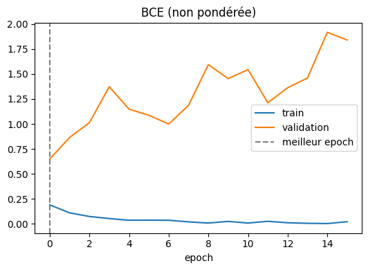

**Validation (orange) monte dès l’epoch 0**

entraînement ≈ 0 = il connaît les réponses par cœur, mais se trompe sur les nouvelles souches

50 COLONNES

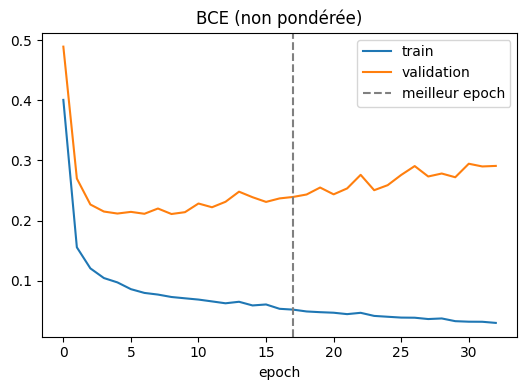

**Les deux courbes baissent ensemble**

meilleur epoch : 17 → il apprend vraiment avant de commencer à sur-apprendre

Passage à 8 antibiotiques

Même méthode, 8 antibiotiques : de 0,98 à 0,51 selon l’antibiotique

PR-AUC sur le test · XGBoost

= score du hasard

ciprofloxacine

0,98

facile

ampicilline

0,96

facile

triméthoprime-sulfa.

0,85

moyen

céfotaxime

0,84

moyen

gentamicine

0,81

moyen

ceftazidime

0,72

moyen

céfuroxime

0,65

difficile

amoxicilline-clav.

0,51

difficile

Pourquoi de tels écarts ?

Ce qui compte, c’est le nombre de façons de résister, pas le nombre de résistantes

Ciprofloxacine

de résistantes

0,98

score

**1 cause principale** : quelques mutations ciblées (gyrA, parC)

Amoxicilline + acide clavulanique

31 %

de résistantes

0,51

score

**plusieurs causes** : enzymes qui cassent l’antibiotique (souvent sur des plasmides), porines, pompes

Choisir l’antibiotique, c’est déjà **définir la difficulté** du problème

Limites et suite

Ce qu’on ne peut pas encore affirmer

Petit jeu de test

154 résistantes → marge d’erreur large

Pas de validation externe

autre hôpital, autre pays : à tester

Un seul découpage

pas de répétitions → variabilité inconnue

Mécanismes absents

plasmides, pompes d’efflux, gènes qnr

Et après ?

répéter + intervalles de confiance

un modèle pour tous les antibiotiques

ajouter les gènes de β-lactamases

Conclusion

3 messages à retenir

1

L’ADN permet de prédire la résistance

ciprofloxacine : 91 % des résistantes détectées, sur des familles jamais vues

2

Un modèle simple suffit, et il retrouve la biologie

68 colonnes sur 20 929, avec en tête les 3 mutations connues de gyrA et parC

3

La difficulté dépend de l’antibiotique

de 0,98 à 0,51 : quelques mutations = facile, plusieurs mécanismes = difficile

[figure not shown]

Merci !

Des questions ?

Benjamin Hin · Alexandre Aitour · Baptiste Jacquet